# Mahalanobis Outlier Detection

SHMTools Example - Parametric_Detectors Level

← Back to Index [GitHub Repository](https://github.com/shmtools/shmtools-python) [Documentation](https://shmtools.readthedocs.io)

# Outlier Detection Based on Mahalanobis Distance

## Introduction

The goal of this example is to discriminate undamaged and damaged structural state conditions based on outlier detection. The parameters from an autoregressive (AR) model are used as damage-sensitive features and a machine learning algorithm based on the Mahalanobis distance is used to create damage indicators (DIs) invariant for feature vectors from normal structural condition and that increase when feature vectors are from damaged structural conditions.

Data sets of an array of sensors from Channel 2-5 of the base-excited three story structure are used in this example. More details about the data sets can be found in the [3-Story Data Sets documentation](https://www.lanl.gov/projects/ei).

This example demonstrates:

1. **Data Loading**: 3-story structure dataset with 4 channels, multiple conditions
2. **Feature Extraction**: AR(15) model parameters from channels 2-5 (not RMSE as in PCA example)
3. **Train/Test Split**: Training on conditions 1-9, testing on conditions 1-9 (baseline) + 10-17 (damage)
4. **Mahalanobis Modeling**: Learn mean and covariance from training features
5. **Damage Detection**: Score test data and apply 95% threshold for classification
6. **Visualization**: Time histories, feature plots, damage indicator bar charts

**References:**

Worden, K., & Manson, G. (2000). Damage Detection using Outlier Analysis. Journal of Sound and Vibration, 229 (3), 647-667.

**SHMTools functions used:**

- `ar_model_shm`
- `learn_mahalanobis_shm`
- `score_mahalanobis_shm`

```python
import numpy as np
import matplotlib.pyplot as plt

# Import shmtools (installed package)
from examples.data import import_3story_structure_shm
from shmtools.features.time_series import ar_model_shm
from shmtools.classification.outlier_detection import learn_mahalanobis_shm, score_mahalanobis_shm

# Set up plotting
plt.style.use('default')
plt.rcParams['figure.figsize'] = (12, 8)
plt.rcParams['font.size'] = 10
```

## Load Raw Data

Load the 3-story structure dataset and extract channels 2-5 for analysis.

```python
# Load data set
dataset, damage_states, state_list = import_3story_structure_shm()
# Use default values since we don't have access to the old data_dict metadata
fs = 100  # Default sampling frequency
channels = ['Force', 'Channel 2', 'Channel 3', 'Channel 4', 'Channel 5']
# Convert state_list to match expected format (flatten and convert to int)
damage_states = state_list.flatten().astype(int)

print(f"Dataset shape: {dataset.shape}")
print(f"Sampling frequency: {fs} Hz")
print(f"Channels: {channels}")
print(f"Number of damage states: {len(np.unique(damage_states))}")

# Extract channels 2-5 (indices 1-4 in Python)
data = dataset[:, 1:5, :]
t, m, n = data.shape

print(f"\nData for analysis:")
print(f"Time points: {t}")
print(f"Channels: {m} (Ch2-Ch5)")
print(f"Conditions: {n}")
```

```
Dataset shape: (8192, 5, 170)
Sampling frequency: 100 Hz
Channels: ['Force', 'Channel 2', 'Channel 3', 'Channel 4', 'Channel 5']
Number of damage states: 17

Data for analysis:
Time points: 8192
Channels: 4 (Ch2-Ch5)
Conditions: 170
```

### Plot Time History from Baseline and Damaged Conditions

The figure below plots time histories from State#1 (baseline condition, black) and State#16 (damaged with simulated operational changes, red) in concatenated format.

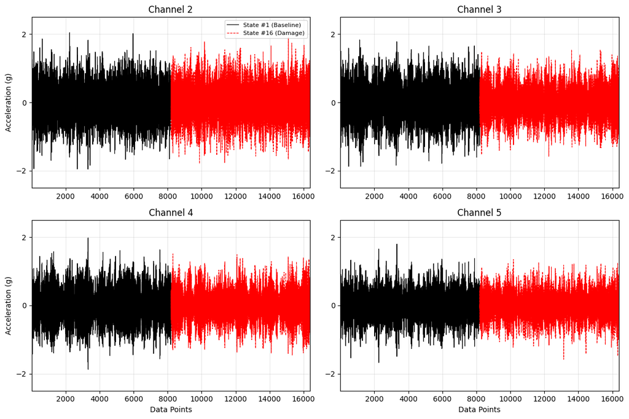

```python
# Channel labels
labels = ['Channel 2', 'Channel 3', 'Channel 4', 'Channel 5']

fig, axes = plt.subplots(2, 2, figsize=(12, 8))
axes = axes.flatten()

time_1 = np.arange(1, t+1)
time_2 = np.arange(t+1, 2*t+1)

for i in range(m):
    # State #1 (condition index 0) and State #16 (condition index 150)
    baseline_signal = data[:, i, 0]   # First condition (State 1)
    damaged_signal = data[:, i, 150]  # Condition 151 (State 16, damaged with operational changes)

    axes[i].plot(time_1, baseline_signal, 'k-', label='State #1 (Baseline)', linewidth=0.8)
    axes[i].plot(time_2, damaged_signal, 'r--', label='State #16 (Damage)', linewidth=0.8)

    axes[i].set_title(labels[i])
    axes[i].set_ylim([-2.5, 2.5])
    axes[i].set_xlim([1, 2*t])
    axes[i].set_yticks([-2, 0, 2])
    axes[i].grid(True, alpha=0.3)

    if i >= 2:  # Bottom row
        axes[i].set_xlabel('Data Points')
    if i % 2 == 0:  # Left column
        axes[i].set_ylabel('Acceleration (g)')

    if i == 0:  # Add legend to first subplot
        axes[i].legend(loc='upper right', fontsize=8)

plt.tight_layout()
plt.show()
```

## Extraction of Damage-Sensitive Features

This section estimates the AR(15) model parameters from the time histories of Channels 2-5 and plots the feature vectors for each instance (or condition). **Note**: Unlike the PCA example, this uses AR parameters directly as features, not the RMSE values.

```python
# AR model order
ar_order = 15

print(f"Extracting AR({ar_order}) model parameters as features...")

# Estimation of AR Parameters (we need the parameters, not RMSE)
ar_parameters_fv, rmse_fv, ar_parameters, ar_residuals, ar_prediction = ar_model_shm(data, ar_order)

print(f"AR parameters FV shape: {ar_parameters_fv.shape}")
print(f"RMSE shape: {rmse_fv.shape}")
print(f"AR parameters shape: {ar_parameters.shape}")

# Use AR parameters as features (not RMSE as in PCA example)
features = ar_parameters_fv  # Shape: (instances, features) where features = channels * ar_order
print(f"Features shape: {features.shape} (instances, channels*ar_order)")
```

```
Extracting AR(15) model parameters as features...
```

```
AR parameters FV shape: (170, 60)
RMSE shape: (170, 4)
AR parameters shape: (15, 4, 170)
Features shape: (170, 60) (instances, channels*ar_order)
```

### Prepare Training and Test Data

Following the original MATLAB example exactly:

- **Training Data**: From conditions 1-9 (first 9 from each of the first 9 damage states)
- **Test Data**: Every 10th condition from all damage states (conditions 10, 20, 30, ..., 170)

```python
# Training Data - following MATLAB exactly
# for i=1:9; learnData(i*9-8:i*9,:)=arParameters(i*10-9:i*10-1,:); end
num_features = features.shape[1]
learn_data = np.zeros((9*9, num_features))  # 81 samples x (4 channels * 15 AR params)

for i in range(1, 10):  # i = 1 to 9
    start_idx = i*9 - 8 - 1  # Convert to 0-based indexing
    end_idx = i*9 - 1

    features_start_idx = i*10 - 9 - 1  # Convert to 0-based indexing
    features_end_idx = i*10 - 1 - 1

    learn_data[start_idx:end_idx+1, :] = features[features_start_idx:features_end_idx+1, :]

# Test Data - every 10th condition
# scoreData=arParameters(10:10:170,:)
test_indices = np.arange(9, 170, 10)  # 10:10:170 in MATLAB (0-based: 9:10:169)
score_data = features[test_indices, :]

print(f"Training data shape: {learn_data.shape}")
print(f"Test data shape: {score_data.shape}")
print(f"Test indices (MATLAB 1-based): {test_indices + 1}")

n_test = score_data.shape[0]
```

```
Training data shape: (81, 60)
Test data shape: (17, 60)
Test indices (MATLAB 1-based): [ 10  20  30  40  50  60  70  80  90 100 110 120 130 140 150 160 170]
```

### Plot Test Data Features

Visualization of the extracted AR parameter features showing the feature vectors composed of AR parameters from Channel 2-5.

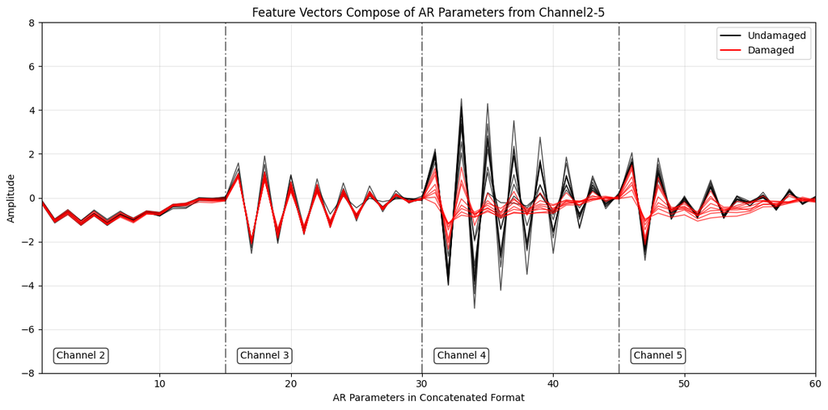

```python
# Plot test data (following MATLAB exactly)
plt.figure(figsize=(12, 6))

# Get dimensions: n = instances, m = features
n_test_plot, m = score_data.shape

# MATLAB: plot(1:m,scoreData(1:9,:)','k',1:m,scoreData(10:17,:)','r')
# Let's try the transpose approach but plot each COLUMN of the transposed matrix

# X-axis: feature indices (1 to m)
feature_indices = np.arange(1, m + 1)

# MATLAB scoreData(1:9,:)' creates a (m x 9) matrix, then plots each column as a line
undamaged_transposed = score_data[:9, :].T  # Shape: (60, 9)
damaged_transposed = score_data[9:17, :].T  # Shape: (60, 8)

# Plot each column of the transposed matrices
for i in range(undamaged_transposed.shape[1]):  # 9 undamaged instances
    plt.plot(feature_indices, undamaged_transposed[:, i], 'k-', linewidth=1, alpha=0.7)

for i in range(damaged_transposed.shape[1]):  # 8 damaged instances
    plt.plot(feature_indices, damaged_transposed[:, i], 'r-', linewidth=1, alpha=0.7)

plt.title('Feature Vectors Compose of AR Parameters from Channel2-5')
plt.xlabel('AR Parameters in Concatenated Format')
plt.ylabel('Amplitude')
plt.xlim([1, m])
plt.ylim([-8, 8])

# Add legend (MATLAB style)
# Create dummy lines for legend
import matplotlib.lines as mlines
undamaged_line = mlines.Line2D([], [], color='k', label='Undamaged')
damaged_line = mlines.Line2D([], [], color='r', label='Damaged')
plt.legend(handles=[undamaged_line, damaged_line])

plt.grid(True, alpha=0.3)

# Add vertical separator lines (MATLAB: m/4, m/4*2, m/4*3)
for i in range(1, 4):
    plt.axvline(x=m/4 * i, color='k', linestyle='-.', alpha=0.5)

# Add channel labels (following MATLAB text positions)
# MATLAB positions: 4, 18, 33, 48 for channels 2-5
plt.text(4, -7, 'Channel 2', ha='center', va='top',
         bbox=dict(boxstyle='round', facecolor='white', edgecolor='k', alpha=0.8))
plt.text(18, -7, 'Channel 3', ha='center', va='top',
         bbox=dict(boxstyle='round', facecolor='white', edgecolor='k', alpha=0.8))
plt.text(33, -7, 'Channel 4', ha='center', va='top',
         bbox=dict(boxstyle='round', facecolor='white', edgecolor='k', alpha=0.8))
plt.text(48, -7, 'Channel 5', ha='center', va='top',
         bbox=dict(boxstyle='round', facecolor='white', edgecolor='k', alpha=0.8))

plt.tight_layout()
plt.show()
```

## Statistical Modeling for Feature Classification

The Mahalanobis-based machine learning algorithm is used to normalize the features and reduce each feature vector into a score.

```python
# Learn Mahalanobis model from training data
print("Learning Mahalanobis model from training data...")
model = learn_mahalanobis_shm(learn_data)

print(f"Mahalanobis model mean shape: {model['dataMean'].shape}")
print(f"Mahalanobis model covariance shape: {model['dataCov'].shape}")

# Score test data using the learned model
print("\nScoring test data...")
DI = score_mahalanobis_shm(score_data, model)

print(f"Damage indicators shape: {DI.shape}")
print(f"\nDamage indicators (first 10): {DI[:10].flatten()}")
```

```
Learning Mahalanobis model from training data...
Mahalanobis model mean shape: (1, 60)
Mahalanobis model covariance shape: (60, 60)

Scoring test data...
Damage indicators shape: (17, 1)

Damage indicators (first 10): [  -273.72689665    -83.26014276   -402.24515448   -187.25247404
   -602.89661502   -144.91647926   -428.29840134   -638.11536268
  -1210.5414206  -44195.33217965]
```

## Outlier Detection

Threshold determination based on the 95% cut-off over the training data and visualization of damage indicators.

```python
# Threshold based on the 95% cut-off over the training data
print("Computing threshold from training data...")
threshold_scores = score_mahalanobis_shm(learn_data, model)
threshold_sorted = np.sort(-threshold_scores.flatten())  # Sort negative scores (following MATLAB)

# MATLAB: UCL=threshold(round(length(threshold)*0.95));
# In MATLAB (1-indexed): round(81*0.95) = round(76.95) = 77, so threshold(77)
# In Python (0-indexed): we want index 76, so threshold_sorted[76]
matlab_index = int(np.round(len(threshold_sorted) * 0.95))  # This gives 77 (MATLAB 1-based)
python_index = matlab_index - 1  # Convert to 0-based: 77-1=76
UCL = threshold_sorted[python_index]

print(f"Upper Control Limit (UCL): {UCL:.6f}")
print(f"Number of training samples: {len(threshold_scores)}")
print(f"MATLAB index (1-based): {matlab_index}")
print(f"Python index (0-based): {python_index}")
```

```
Computing threshold from training data...
Upper Control Limit (UCL): 71.931353
Number of training samples: 81
MATLAB index (1-based): 77
Python index (0-based): 76
```

### Plot Damage Indicators

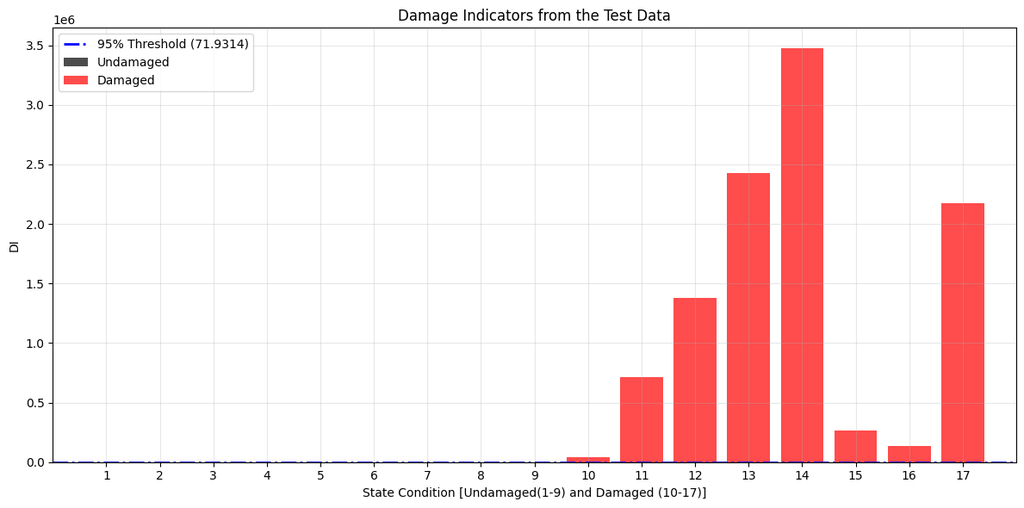

```
Classification Results:
==================================================
State  1 (Undamaged): DI = 273.7269 → DAMAGE ✗
State  2 (Undamaged): DI =  83.2601 → DAMAGE ✗
State  3 (Undamaged): DI = 402.2452 → DAMAGE ✗
State  4 (Undamaged): DI = 187.2525 → DAMAGE ✗
State  5 (Undamaged): DI = 602.8966 → DAMAGE ✗
State  6 (Undamaged): DI = 144.9165 → DAMAGE ✗
State  7 (Undamaged): DI = 428.2984 → DAMAGE ✗
State  8 (Undamaged): DI = 638.1154 → DAMAGE ✗
State  9 (Undamaged): DI = 1210.5414 → DAMAGE ✗
State 10 (Damaged  ): DI = 44195.3322 → DAMAGE ✓
State 11 (Damaged  ): DI = 711002.2217 → DAMAGE ✓
State 12 (Damaged  ): DI = 1378963.1367 → DAMAGE ✓
State 13 (Damaged  ): DI = 2428767.4812 → DAMAGE ✓
State 14 (Damaged  ): DI = 3473542.8320 → DAMAGE ✓
State 15 (Damaged  ): DI = 264767.7399 → DAMAGE ✓
State 16 (Damaged  ): DI = 132530.0231 → DAMAGE ✓
State 17 (Damaged  ): DI = 2173747.5946 → DAMAGE ✓

Performance Summary:
Undamaged correctly classified: 0/9
Damaged correctly classified: 8/8
Overall accuracy: 8/17 (47.1%)
False positives: 9
False negatives: 0
```

```python
# Plot DIs
plt.figure(figsize=(12, 6))

state_conditions = np.arange(1, n_test + 1)

# Undamaged conditions (1-9)
plt.bar(state_conditions[:9], -DI[:9].flatten(), color='k', alpha=0.7, label='Undamaged')

# Damaged conditions (10-17)
plt.bar(state_conditions[9:17], -DI[9:17].flatten(), color='r', alpha=0.7, label='Damaged')

plt.title('Damage Indicators from the Test Data')
plt.xlim([0, n_test + 1])
plt.xticks(state_conditions)
plt.xlabel('State Condition [Undamaged(1-9) and Damaged (10-17)]')
plt.ylabel('DI')
plt.legend()
plt.grid(True, alpha=0.3)

# Add threshold line
plt.axhline(y=UCL, color='b', linestyle='-.', linewidth=2, label=f'95% Threshold ({UCL:.4f})')
plt.legend()

plt.tight_layout()
plt.show()

# Print classification results
print("\nClassification Results:")
print("=" * 50)
for i in range(n_test):
    state_type = "Undamaged" if i < 9 else "Damaged"
    detected = "DAMAGE" if -DI[i, 0] > UCL else "normal"
    status = "✓" if (i < 9 and detected == "normal") or (i >= 9 and detected == "DAMAGE") else "✗"
    print(f"State {i+1:2d} ({state_type:9s}): DI = {-DI[i, 0]:8.4f} → {detected:6s} {status}")

# Calculate performance metrics
undamaged_correct = np.sum(-DI[:9, 0] <= UCL)
damaged_correct = np.sum(-DI[9:17, 0] > UCL)
total_correct = undamaged_correct + damaged_correct

print(f"\nPerformance Summary:")
print(f"Undamaged correctly classified: {undamaged_correct}/9")
print(f"Damaged correctly classified: {damaged_correct}/8")
print(f"Overall accuracy: {total_correct}/{n_test} ({100*total_correct/n_test:.1f}%)")
print(f"False positives: {9 - undamaged_correct}")
print(f"False negatives: {8 - damaged_correct}")
```

## Summary

This example demonstrated the complete Mahalanobis distance-based outlier detection workflow for structural health monitoring:

**Key differences from PCA approach:**

- Uses AR parameters directly as features (not RMSE values)
- Computes Mahalanobis distance instead of PCA reconstruction error
- Simpler statistical model (mean + covariance vs. principal components)
- More direct interpretation of feature importance

**Key advantages of Mahalanobis distance:**

- Accounts for feature correlations through covariance matrix
- Scale-invariant distance metric
- Well-established statistical foundation
- Computationally efficient
- Robust to multivariate outliers when training data is clean

**See also:**

- Outlier Detection based on Principal Component Analysis
- Outlier Detection based on the Singular Value Decomposition
- Outlier Detection based on the Factor Analysis Model
- Outlier Detection based on Nonlinear Principal Component Analysis

Generated on 2025-08-23 22:58:15 from `mahalanobis_outlier_detection.ipynb`

Part of the SHMTools Python Package - Structural Health Monitoring Toolkit